# TP2 - Statistique avec R

ModIA - 4ème année - 2023-2024

Ce TP se décompose en deux parties indépendantes :

- Partie 1 : elle est consacrée aux notions de statistiques descriptives uni- et bi-dimensionnelles.
- Partie 2 : elle est consacrée à l’illustration de notions de statistique inférentielle paramétrique revues dans les séances de remise à niveau. On n’abordera ici que le cas gaussien.

*Remarque : pensez à enlever les “eval=F” au fur et à mesure de l’avancement dans le TP dans la partie 2 pour avoir les résultats dans votre compte-rendu final de TP.*

# Statistiques descriptives

On reprend dans cette section une grande partie du [tutoriel 3](https://cmaugis.github.io/TutorielsR/Part3-StatR.html). Avant de commencer ce TP, vous devez lire la présentation de `ggplot2` du [tutoriel 4](https://cmaugis.github.io/TutorielsR/Part4-Ravance.html#visualisation-avec-ggplot2).

## Récupération du jeu de données

On va étudier le jeu de données **wine** disponible sur la page moodle du cours. Commencez par récupérer ce jeu de données et sauvegardez le fichier dans votre dossier de travail.

Le jeu de données **wine** comprend des mesures physico-chimiques réalisées sur un échantillon de $600$ vins (rouges et blancs) du Portugal. Ces mesures sont complétées par une évaluation sensorielle de la qualité par un ensemble d’experts. Chaque vin est décrit par les variables suivantes :

- *Qualite* : son évaluation sensorielle par les experts (“bad”,“medium”,“good”),
- *Type* : son type (1 pour un vin rouge, 0 pour un vin blanc),
- *AcidVol* : la teneur en acide volatile (en g/dm3 d’acide acétique),
- *AcidCitr* : la teneur en acide citrique (en g/dm3),
- *SO2lbr* : le dosage du dioxyde de soufre libre (en mg/dm3),
- *SO2tot* : le dosage du dioxyde de soufre total (en mg/dm3),
- *Densite* : la densité (en g/cm3),
- *Alcool* : le degré d’alcool (en % Vol.).

Dans un premier temps, commencez par charger le jeu de données à l’aide de la fonction `read.table()`.

```r
Data = read.table("wine.txt",header=TRUE)
```

Vous pouvez voir les premières lignes du jeu de données :

```r
head(Data)
```

```
     Qualite Type AcidVol AcidCitr SO2lbr SO2tot Densite Alcool
1352  medium    1    0.62     0.01      8     46 0.99332   11.8
5493  medium    0    0.34     0.10     17     63 0.99370    9.2
5153  medium    0    0.22     0.22     39    110 0.99855    9.0
5308  medium    0    0.35     0.46     61    183 0.99786    9.0
3866  medium    0    0.42     0.32     20    167 0.99479   10.6
694   medium    1    0.48     0.32     21    122 0.99840    9.4
```

Le jeu de données contient 600 individus (correspondant aux 600 lignes) décrits par 8 variables (correspondant aux 8 colonnes).

Remarquons que l’on peut obtenir les noms des variables grâce à la commande `names(Data)`. Plus largement, on peut utiliser la commande `attributes()` :

```r
attributes(Data)
```

```
$names
[1] "Qualite"  "Type"     "AcidVol"  "AcidCitr" "SO2lbr"   "SO2tot"   "Densite"
[8] "Alcool"

$class
[1] "data.frame"

$row.names
 [1] "1352" "5493" "5153" "5308" "3866" "694"  "5085" "2280" "5231" "4388"
[11] "4172" "4763" "4001" "3244" "4663" "3256" "3444" "3867" "3161" "6420"
[21] "1590" "2155" "2258" "209"  "4560" "1981" "2166" "5430" "6496" "346"
[31] "1288" "3615" "1837" "5637" "2520" "3046" "2983" "840"  "3185" "4690"
[41] "6347" "728"  "240"  "6318" "2501" "3003" "4537" "4799" "141"  "3664"
[51] "5167" "5291" "3383" "2712" "449"  "214"  "3216" "4917" "5005" "3501"
[61] "1291" "3137" "998"  "1350" "6336" "492"  "3901" "4878" "5343" "5096"
[71] "4516" "1118" "2680" "452"  "3937"
 [ reached getOption("max.print") -- omitted 525 entries ]
```

La commande `str()` affiche quand à elle d’autres informations concernant les données. En particulier, on retrouve le type (data.frame) et la dimension (nombres d’observations et de variables) des données. En outre, pour chaque variable, on peut lire son nom, son format (entier, numérique, caractère) ainsi que ses premières valeurs.

```r
str(Data)
```

```
'data.frame':   600 obs. of  8 variables:
 $ Qualite : chr  "medium" "medium" "medium" "medium" ...
 $ Type    : int  1 0 0 0 0 1 0 0 0 0 ...
 $ AcidVol : num  0.62 0.34 0.22 0.35 0.42 0.48 0.21 0.28 0.3 0.4 ...
 $ AcidCitr: num  0.01 0.1 0.22 0.46 0.32 0.32 0.32 0.14 0.25 0.42 ...
 $ SO2lbr  : num  8 17 39 61 20 21 39 64 21 41 ...
 $ SO2tot  : int  46 63 110 183 167 122 113 159 124 176 ...
 $ Densite : num  0.993 0.994 0.999 0.998 0.995 ...
 $ Alcool  : num  11.8 9.2 9 9 10.6 9.4 10.2 10 10.8 9.4 ...
```

On voit ici que les variables sont de différentes natures :

- Les variables *Qualite* et *Type* sont des variables *qualitatives*
- Les autres variables sont *quantitatives*

Attention à bien préciser à R les variables qui doivent être considérées comme qualitatives. Ici, on change donc la nature des variables *Qualite* et *Type*:

```r
Data$Qualite=as.factor(Data$Qualite)
Data$Type=factor(Data$Type,labels=c("blanc","rouge"))
head(Data)
```

```
     Qualite  Type AcidVol AcidCitr SO2lbr SO2tot Densite Alcool
1352  medium rouge    0.62     0.01      8     46 0.99332   11.8
5493  medium blanc    0.34     0.10     17     63 0.99370    9.2
5153  medium blanc    0.22     0.22     39    110 0.99855    9.0
5308  medium blanc    0.35     0.46     61    183 0.99786    9.0
3866  medium blanc    0.42     0.32     20    167 0.99479   10.6
694   medium rouge    0.48     0.32     21    122 0.99840    9.4
```

On peut obtenir un résumé rapide du jeu de données à l’aide de la fonction `summary()`

```r
summary(Data)
```

```
   Qualite       Type        AcidVol          AcidCitr          SO2lbr
 bad   : 19   blanc:425   Min.   :0.1000   Min.   :0.0000   Min.   :  2.00
 good  :110   rouge:175   1st Qu.:0.2400   1st Qu.:0.2400   1st Qu.: 15.75
 medium:471               Median :0.3000   Median :0.3000   Median : 27.00
                          Mean   :0.3512   Mean   :0.3141   Mean   : 29.41
                          3rd Qu.:0.4300   3rd Qu.:0.3900   3rd Qu.: 41.00
                          Max.   :1.0400   Max.   :1.0000   Max.   :112.00
     SO2tot         Densite           Alcool
 Min.   :  7.0   Min.   :0.9875   Min.   : 8.00
 1st Qu.: 68.0   1st Qu.:0.9925   1st Qu.: 9.50
 Median :114.5   Median :0.9949   Median :10.40
 Mean   :111.2   Mean   :0.9947   Mean   :10.49
 3rd Qu.:154.0   3rd Qu.:0.9970   3rd Qu.:11.30
 Max.   :278.0   Max.   :1.0030   Max.   :14.00
```

## Statistiques descriptives unidimensionnelles

### Variable qualitative

On considère ici une variable qualitative $X$ dont on observe $n$ réalisations $\underline{x}=(x_1,x_2,\ldots,x_n)$. Cette variable prend $K$ modalités $m_1,\ldots,m_K$. Si les modalités n’ont pas d’ordre naturel, on parle de variable qualitative nominale (ex. *Type*), sinon c’est une variable qualitative ordinale (ex. *Qualite*).

La variable *Type* contient $K=$ 2 modalités qui sont blanc, rouge.

```r
levels(Data$Type)
```

```
[1] "blanc" "rouge"
```

On récupère l’effectif $n_k=\sum_{i=1}^n \mathbb{1}_{x_i=m_k}$ pour chaque modalité $m_k$ avec `summary()` ou `table()`.

```r
summary(Data$Type)
```

```
blanc rouge
  425   175
```

```r
EffType = as.vector(table(Data$Type))
EffType
```

```
[1] 425 175
```

On utilise aussi les fréquences $f_k=\frac{n_k}{n}$ donc $\sum_{k=1}^K f_k=1$.

```r
Freq = EffType/length(Data$Type)
knitr::kable(data.frame(modalite=levels(Data$Type),Eff=EffType,Freq=Freq), caption = 'Description de la variable Type',booktabs = TRUE,digits=3)
```

Description de la variable Type

| modalite | Eff | Freq |
| --- | --- | --- |
| blanc | 425 | 0.708 |
| rouge | 175 | 0.292 |

Pour une variable qualitative ordinale, on utilise également les effectifs cumulés $N_k=\sum_{\ell=1}^k n_\ell$ et les fréquences cumulées $F_k=\sum_{\ell=1}^k f_\ell$.

Pour une variable qualitative, on utilise la représentation par camembert (pie) ou diagramme en bâton (barplot)

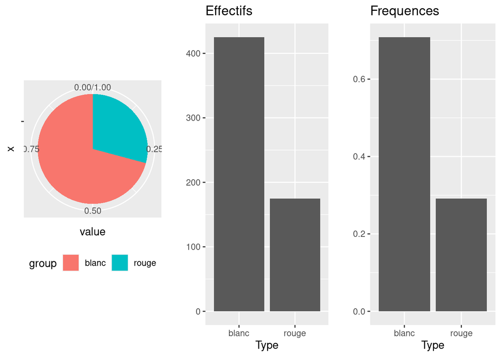

```r
g1<-ggplot(Data, aes(x=Type))+ geom_bar()+ylab("")+ggtitle("Effectifs")
g2<-ggplot(Data, aes(x = Type)) +
  geom_bar(aes(y = (..count..)/sum(..count..)))+ylab("")+ggtitle("Frequences")
quan <- as.vector(table(Data$Type))/nrow(Data)
df <- data.frame(group = levels(Data$Type),value = quan)
g3<-ggplot(df, aes(x="", y=value, fill=group))+
  geom_bar(width = 1, stat = "identity")+ coord_polar("y", start=0)+ theme(legend.position="bottom")
grid.arrange(g3,g1,g2,ncol=3)
```

Pour une variable qualitative ordinale, on peut également tracer les fréquences cumulées :

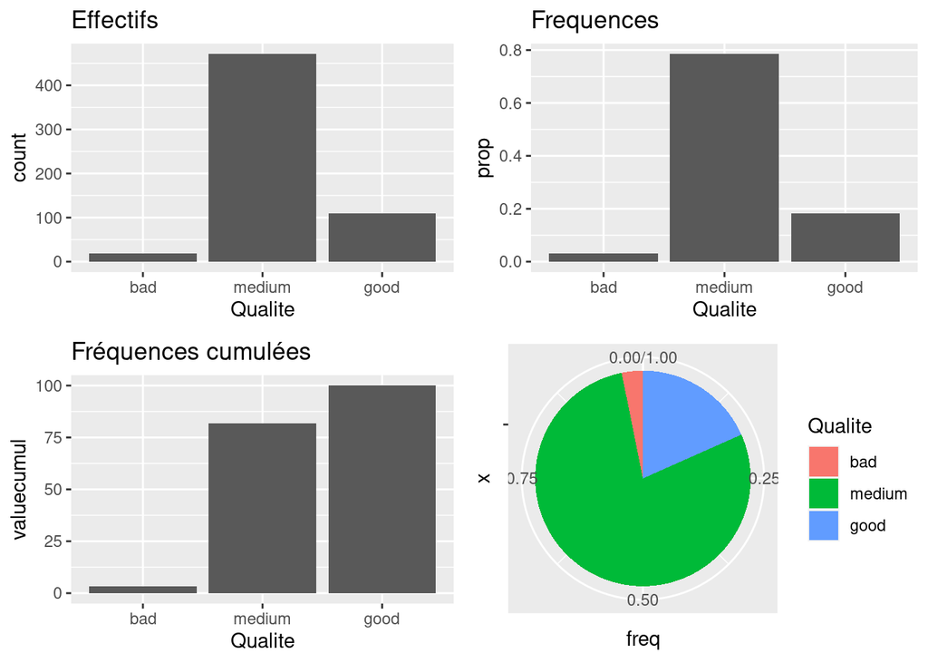

### Variable quantitative

Nous allons ici nous intéresser à l’étude d’une variable quantitative $X$ dont on a $n$ observations $\underline{x}=(x_1,\ldots,x_n)$. On va illustrer cette section avec la variable *Alcool*. Vous pouvez reprendre l’étude pour les autres variables quantitatives du jeu de données.

#### Indices statistiques

Nous rappelons les principaux indicateurs statistiques que l’on peut évaluer pour une série de mesures $\underline{x}$ : la moyenne, la médiane, la variance, l’écart-type ….

##### Mean/var/sd

La moyenne de $\underline{x}$ : $\bar{x} = \frac{1}{n} \sum_{i=1}^n x_i$

```r
mean(Data$Alcool)
```

```
[1] 10.48592
```

La variance $s_x^2 = \frac{1}{n}\sum_{i=1}^n (x_i - \bar{x})^2$, la variance corrigée $var(\underline{x})=\frac{1}{n-1}\sum_{i=1}^n (x_i - \bar{x})^2$ et l’écart-type corrigé $\sqrt{var(\underline{x})}$. Attention les fonctions `var()` et `sd()` renvoient les valeurs corrigées de la variance et de l’écart-type respectivement.

```r
var(Data$Alcool)
```

```
[1] 1.316059
```

```r
sd(Data$Alcool)
```

```
[1] 1.147196
```

##### min/max/range

La commande `range()` renvoie respectivement le minimum et le maximum. On peut aussi utiliser `min()`et `max()`

```r
range(Data$Alcool)
```

```
[1]  8 14
```

```r
min(Data$Alcool)
```

```
[1] 8
```

```r
max(Data$Alcool)
```

```
[1] 14
```

On peut alors récupérer l’étendue ($max(\underline{x}) - min(\underline{x})$ ) avec le code suivant :

```r
diff(range(Data$Alcool))
```

```
[1] 6
```

##### médiane / quartiles / quantiles

La médiane est une valeur qui divise l’échantillon en deux sous-échantillons de même cardinal : $\sum_{i=1}^n \mathbb{1}_{x_i\geq m} \geq \frac{n}{2} \textrm{ et } \sum_{i=1}^n \mathbb{1}_{x_i\leq m} \geq \frac{n}{2}$

```r
median(Data$Alcool)
```

```
[1] 10.4
```

```r
sort(Data$Alcool)[296:305]
```

```
 [1] 10.3 10.3 10.3 10.3 10.4 10.4 10.4 10.4 10.4 10.4
```

La médiane est le deuxième des trois quartiles :

Les quartiles sont des cas particuliers de la notion de quantile. Le $\alpha$-quantile empirique est défini par $q_{\alpha} = x_{(i)}$ avec $\alpha\in]\frac{i-1}{n}, \frac{i}{n}]$ où $x_{(1)}\leq x_{(2)}\leq \ldots \leq x_{(n)}$ sont les valeurs ordonnées de la série statistique.

```r
quantile(Data$Alcool)
```

```
  0%  25%  50%  75% 100%
 8.0  9.5 10.4 11.3 14.0
```

```r
quantile(Data$Alcool,0.9)
```

```
 90%
12.1
```

Pour calculer l’écart interquantile, il suffit de faire la différence entre les troisième et premier quantiles, à savoir

```r
q.Alc <- quantile(x = Data$Alcool, probs=c(.25,.75), names=FALSE)
diff(q.Alc)
```

```
[1] 1.8
```

et les valeurs d’adjacence sont obtenues de la manière suivante :

```r
L=q.Alc + diff(q.Alc) * c(-1.5,1.5) ; L
```

```
[1]  6.8 14.0
```

```r
# valeur adjacente inférieure :
min(Data$Alcool[Data$Alcool>=L[1]])
```

```
[1] 8
```

```r
# valeur adjacente supérieure :
max(Data$Alcool[Data$Alcool<=L[2]])
```

```
[1] 14
```

Par ailleurs, toutes ces informations sont stockées dans la commande `summary()` :

```r
summary(Data$Alcool)
```

```
   Min. 1st Qu.  Median    Mean 3rd Qu.    Max.
   8.00    9.50   10.40   10.49   11.30   14.00
```

où sont affichés respectivement le minimum, le premier quartile, la médiane, la moyenne, le troisième quartile et le maximum.

#### Représentations graphiques

##### Histogramme

L’histogramme est une représentation graphique qui permet de visualiser la répartition d’une variable quantitative. Les valeurs sont regroupées en intervalles $]a_k,a_{k+1}[$ et la hauteur associée est $h_k=\frac{f_k}{a_{k+1} - a_k}$.

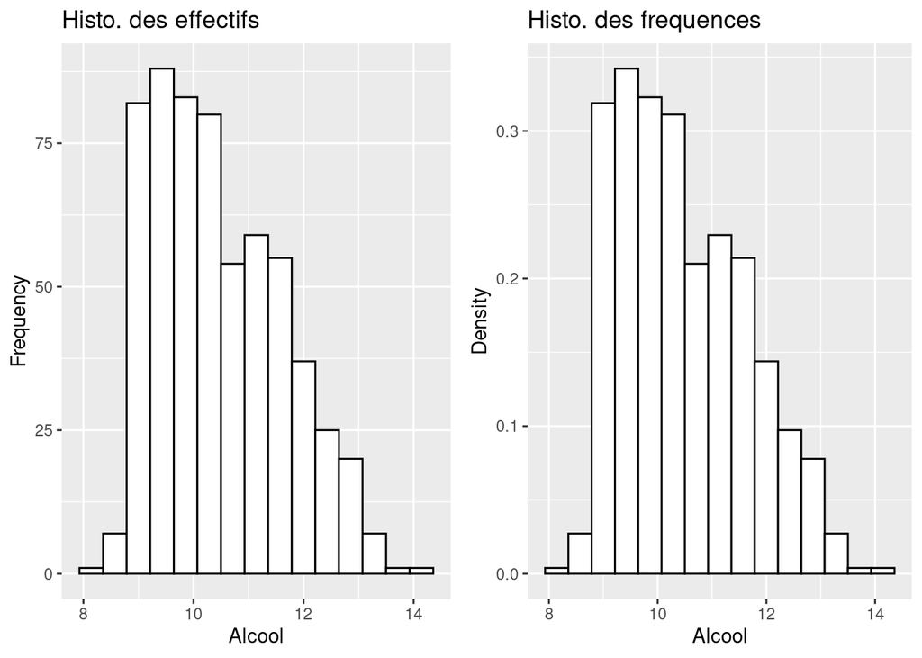

```r
g1<-ggplot(Data,aes(x=Alcool))+geom_histogram(bins=15,color="black", fill="white")+
  ggtitle("Histo. des effectifs")+ylab("Frequency")+xlab("Alcool")
g2<-ggplot(Data,aes(x=Alcool))+geom_histogram(aes(y=..density..),bins=15,color="black", fill="white")+
  ggtitle("Histo. des frequences")+ylab("Density")+xlab("Alcool")
grid.arrange(g1,g2,ncol=2)
```

##### Fonction de répartition empirique

La fonction de répartition empirique est la fonction en escalier définie par $t\in\mathbb{R}\mapsto F_n(t) = \frac{1}{n} \sum_{i=1}^n \mathbb{1}_{x_i\leq t}$

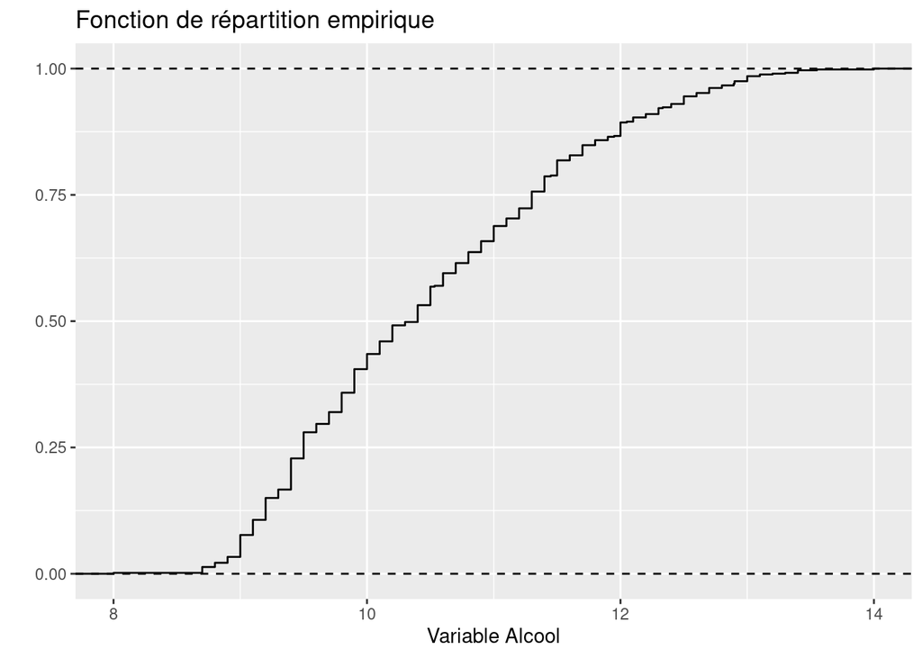

```r
ggplot(Data, aes(Alcool)) +
  stat_ecdf(geom = "step")+xlab("Variable Alcool")+
  ylab("")+ggtitle("Fonction de répartition empirique")+
  geom_hline(yintercept=0, linetype="dashed")+geom_hline(yintercept=1, linetype="dashed")
```

##### Boîte à moustaches / boxplot

La boîte à moustaches est un graphique qui résume la série statistique à partir de ses valeurs extrêmes et ses quartiles. En effet, on retrouve sur cette représentation

- les quartiles
- la valeur adjacente supérieure $v+$, qui est la plus grande valeur de l’échantillon inférieure ou égale à $L+ = q_{0.75} + 1.5 (q _{0.75} − q_{0.25})$
- la valeur adjacente inférieure $v−$, qui est la plus petite valeur de l’échantillon supérieure ou égale à $L− = q_{0.25} − 1.5 (q_{0.75} − q_{0.25})$
- les valeurs extrêmes (outliers) qui sont les valeurs de l’échantillon n’appartenant pas à l’intervalle $[v−, v+]$.

Voici les boxplots pour les variables quantitatives de notre exemple.

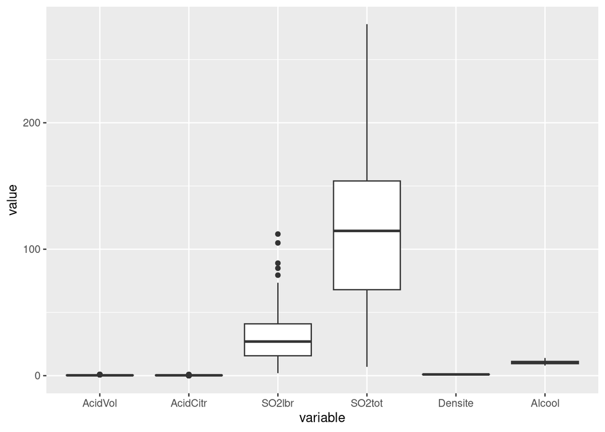

```r
library(reshape2)
ggplot(melt(Data[,-c(1,2)]),aes(x=variable,y=value))+geom_boxplot()
```

Nous allons pour la suite nous concentrer sur la variable *SO2lbr*. En plus du graphique, on peut récupérer de la fonction `boxplot()` différentes informations :

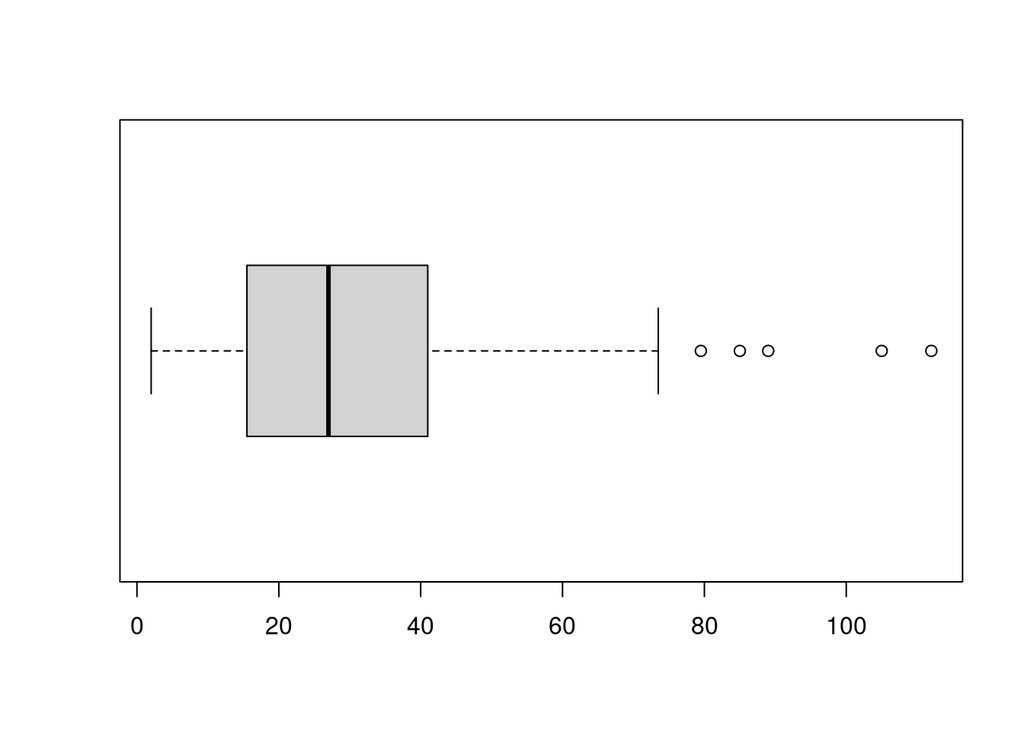

```r
B <- boxplot(Data$SO2lbr,horizontal=TRUE)
```

```r
attributes(B)
```

```
$names
[1] "stats" "n"     "conf"  "out"   "group" "names"
```

Dans `B$stats`, on retrouve les quartiles, la médiane et les valeurs adjacentes :

```r
B$stats
```

```
     [,1]
[1,]  2.0
[2,] 15.5
[3,] 27.0
[4,] 41.0
[5,] 73.5
```

```r
median(Data$SO2lbr)
```

```
[1] 27
```

```r
q <- quantile(x = Data$SO2lbr, probs=c(.25,.75), names=FALSE)
q
```

```
[1] 15.75 41.00
```

```r
L=q + diff(q) * c(-1.5,1.5)
min(Data$SO2lbr[Data$SO2lbr>=L[1]])
```

```
[1] 2
```

```r
max(Data$SO2lbr[Data$SO2lbr<=L[2]])
```

```
[1] 73.5
```

Dans `B$out` renvoie toutes les valeurs aberrantes (en dehors des barres inférieure et supérieure c’est à dire en dehors de l’intervalle $[v-,v+]$):

```r
B$out
```

```
[1]  89.0 105.0  85.0 112.0  79.5
```

```r
Data$SO2lbr[which(Data$SO2lbr<B$stats[1] | Data$SO2lbr>B$stats[5])]
```

```
[1]  89.0 105.0  85.0 112.0  79.5
```

## Statistiques descriptives bidimensionnelles

### Entre 2 variables quantitatives

Supposons dans cette partie que X et Y sont deux variables quantitatives et on observe une série de $n$ valeurs pour chacune : $\underline{x}=(x_1,\ldots,x_n)$ et $\underline{y}=(y_1,\ldots,y_n)$.

On peut tout d’abord représenter le nuage de points de coordonnées $(x_i,y_i)$ :

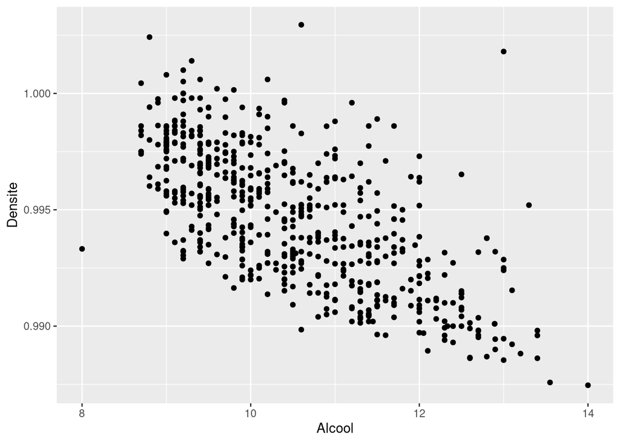

```r
ggplot(Data,aes(x=Alcool,y=Densite))+geom_point()
```

#### Corrélation

On peut calculer la covariance (généralisaton bidimensionnelle de la variance) entre ces deux séries de mesure à l’aide de la commande `cov()`:
$$Cov(\underline{x},\underline{y}) = \frac{1}{n} \sum_{i=1}^n
(x_i-\bar{x}) (y_i -\bar{y}).$$
Mais la covariance dépendant des unités de mesure des deux variables considérées, on calcule plutôt la corrélation linéaire (renormalisation de la covariance par les écarts-type) qui appartient à l’intervalle $[-1,1]$ à l’aide de `cor()`:
$$cor(\underline{x},\underline{y}) =
\frac{Cov(\underline{x},\underline{y})}{\sqrt{s_x^2\ \ s_y^2}}$$

A l’aide de la fonction *corrplot()* (issue du package du même nom) on représente ici la matrice des corrélations entre les variables quantitatives de notre jeu de données:

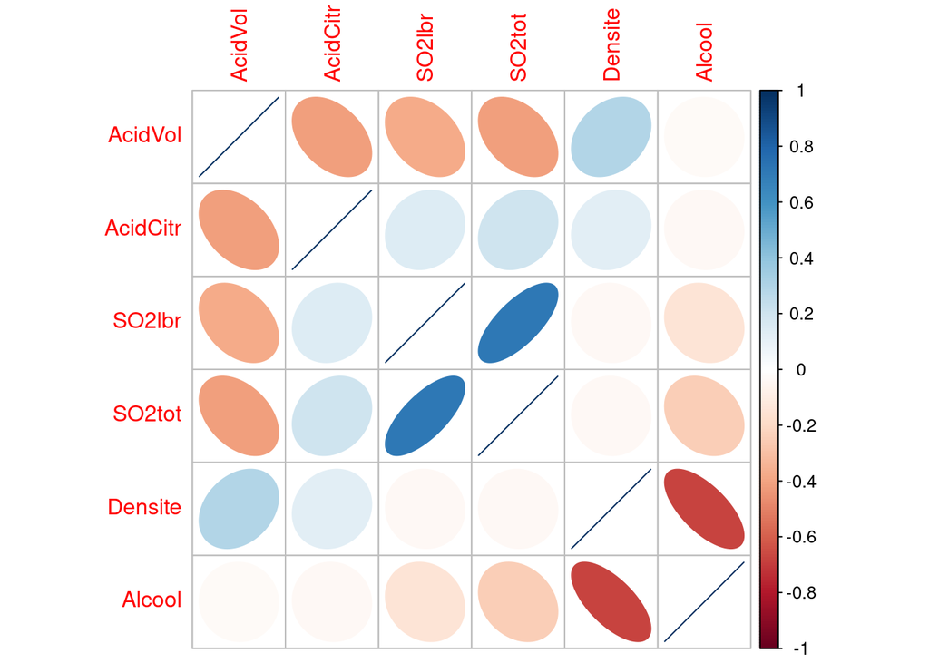

```r
corrplot(cor(Data[,-c(1:2)]),method="ellipse")
```

#### Régression linéaire

Le coefficient de corrélation linéaire entre les variables *Densité* et *Alcool* vaut -0.68. On peut vérifier que le nuage de points de ces deux variables s’aligner sur une droite de pente négative :

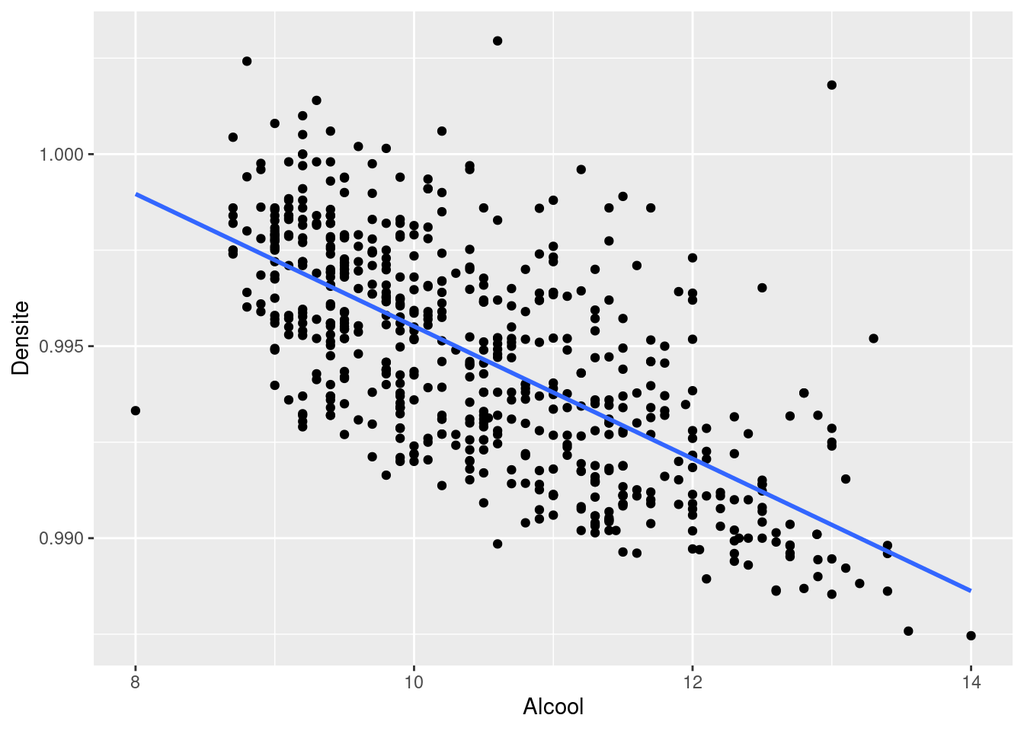

```r
ggplot(Data,aes(x=Alcool,y=Densite))+geom_point()+
  geom_smooth(method=lm, se=FALSE)
```

### Entre une variable quantitative et une variable qualitative

Supposons dans cette partie que $X$ est une variable qualitative prenant $J$ modalités $m_1, \ldots, m_J$ et $Y$ une variable quantitative. On observe une série de $n$ valeurs pour chacune : $\underline{x}=(x_1,\ldots,x_n)$ et $\underline{y}=(y_1,\ldots,y_n)$.

On note $C_j=\{i\in\{1,\ldots,n\}; x_i=m_j\}$ l’ensemble des individus prenant la modalité $m_j$ et $n_j$ son cardinal.

La moyenne de $\underline{y}$ peut alors se décomposer en une moyenne pondérée des moyennes de $y$ conditionnellement aux modalités de $X$ :
$$\bar{y} = \frac{1}{n} \sum_{j=1}^J n_j\ \bar{y}_{[j]}
\textrm{ avec } \bar{y}_{[j]} = \frac{1}{n_j} \sum_{i\in C_j} y_i$$
De même la variance se décompose en $s_y^2 = \underbrace{s_{y,E}^2}_{\textrm{variance inter-classe}} + \underbrace{s_{y,R}^2}_{\textrm{variance intra-classe}}$ avec

$$s_{y,E}^2 = \frac{1}{n} \sum_{j=1}^J n_j\ (\bar{y}_{[j]} - \bar{y})^2$$
et
$$s_{y,R}^2 = \frac{1}{n} \sum_{j=1}^J n_j\ s_{y,[j]}^2 \textrm{ avec }
s^2_{y,[j]} = \frac{1}{n_j}\sum_{i\in C_j} (y_i - \bar{y}_{[j]})^2$$
On peut alors définir le *rapport de corrélation*
$$\rho_{y|x} = \sqrt{\frac{s_{y,E}^2}{s_{y}^2}} = \sqrt{1 -
\frac{s_{y,R}^2}{s_{y}^2}}\in[0,1].$$
Plus $\rho_{y|x}$ est proche de $0$, plus $s_{y,E}^2$ est proche de 0 et donc moins la variable qualitative $X$ a d’influence sur la variable quantitative $Y$.

Graphiquement, on peut représenter la distribution de la variable quantitative conditionnellement aux modalités de la variable qualitative pour visualiser la liaison potentielle entre les deux variables.

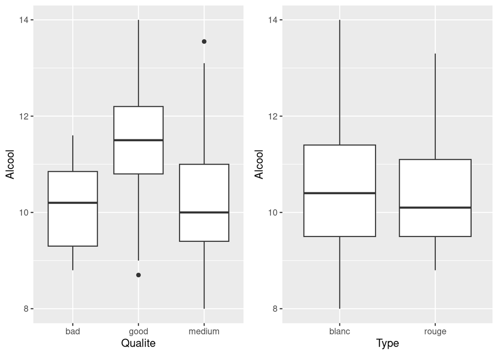

```r
g1<-ggplot(Data,aes(x=Qualite,y=Alcool))+geom_boxplot()
g2<-ggplot(Data,aes(x=Type,y=Alcool))+geom_boxplot()
grid.arrange(g1,g2,ncol=2)
```

### Entre deux variables qualitatives

Supposons dans cette partie que $X$ est une variable qualitative prenant $J$ modalités $m_1,\ldots,m_J$ et $Y$ est une vraiable qualitative prenant $K$ modalités $\ell_1,\ldots,\ell_K$. On observe une série de $n$ valeurs pour chacune : $\underline{x}=(x_1,\ldots,x_n)$ et $\underline{y}=(y_1,\ldots,y_n)$. Pour étudier l’influence de deux variables qualitatives entre elles, on se base sur la table de contingence qui est l’ensemble des effectifs conjoints
$$n_{j,k} = \sum_{i=1}^n \mathrm{1}_{x_i = m_j\ \cap\ y_i=\ell_k},\ \
\forall j\in\{1,\ldots,J\},\ \forall k\in\{1,\ldots,K\}$$
On définit les effectifs marginaux par
$$n_{j,.}=\sum_{k=1}^K n_{j,k}\ \ \ \textrm{ et } \ \ \
n_{.,k}=\sum_{j=1}^J n_{j,k}$$

```r
table.cont = table(Data$Qualite,Data$Type)
table.cont
```

```
         blanc rouge
  bad       17     2
  good      89    21
  medium   319   152
```

Graphiquement, on peut représenter un mosaiplot qui correspond à la représentation des profils-lignes
$$\left(\frac{n_{j,1}}{n_{j,.}},\ldots,\frac{n_{j,K}}{n_{j,.}}\right)\in
[0,1]^K$$
ou des profils-colonnes

$$\left(\frac{n_{1,k}}{n_{.,k}},\ldots,\frac{n_{J,k}}{n_{.,k}}\right)\in
[0,1]^J$$

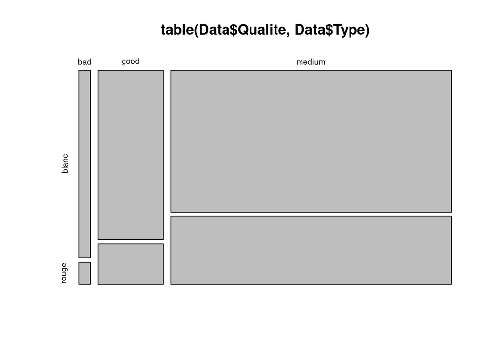

```r
mosaicplot(table(Data$Qualite,Data$Type))
```

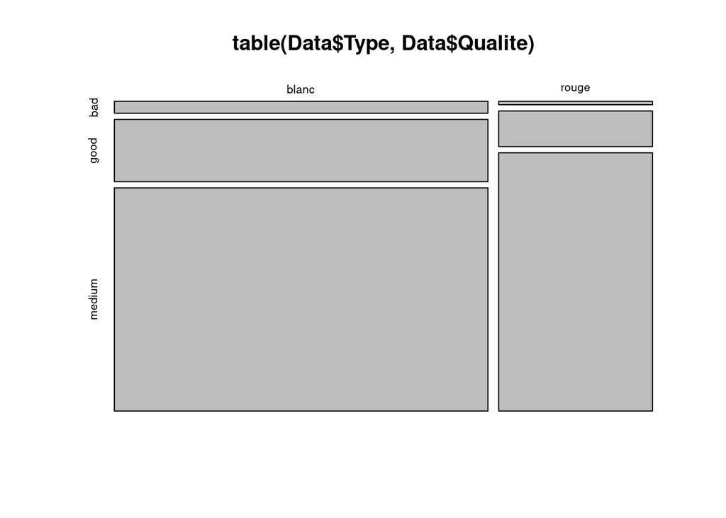

```r
mosaicplot(table(Data$Type,Data$Qualite))
```